# ggplot-tutorial

Ayoush Mukherjee, Charlene Quach

February 19, 2018

Check this github link for the repository to get all code and data: https://github.com/AyoushM/ggplot-visualization-tutorial

## Importing libraries

```r
library(ggplot2)
```

## Importing Midwest Population Dataset

```r
midwest <- read.csv("http://goo.gl/G1K41K")
```

### What do we have here?

```r
length(midwest$PID)
```

```
## [1] 437
```

```r
colnames(midwest)
```

```
##  [1] "PID"                  "county"               "state"
##  [4] "area"                 "poptotal"             "popdensity"
##  [7] "popwhite"             "popblack"             "popamerindian"
## [10] "popasian"             "popother"             "percwhite"
## [13] "percblack"            "percamerindan"        "percasian"
## [16] "percother"            "popadults"            "perchsd"
## [19] "percollege"           "percprof"             "poppovertyknown"
## [22] "percpovertyknown"     "percbelowpoverty"     "percchildbelowpovert"
## [25] "percadultpoverty"     "percelderlypoverty"   "inmetro"
## [28] "category"
```

### What do we have here (v2)?

```r
summary(midwest)
```

```
##       PID            county    state         area
##  Min.   : 561   CRAWFORD:  5   IL:102   Min.   :0.00500
##  1st Qu.: 670   JACKSON :  5   IN: 92   1st Qu.:0.02400
##  Median :1221   MONROE  :  5   MI: 83   Median :0.03000
##  Mean   :1437   ADAMS   :  4   OH: 88   Mean   :0.03317
##  3rd Qu.:2059   BROWN   :  4   WI: 72   3rd Qu.:0.03800
##  Max.   :3052   CLARK   :  4            Max.   :0.11000
##                 (Other) :410
##     poptotal         popdensity          popwhite          popblack
##  Min.   :   1701   Min.   :   85.05   Min.   :    416   Min.   :      0
##  1st Qu.:  18840   1st Qu.:  622.41   1st Qu.:  18630   1st Qu.:     29
##  Median :  35324   Median : 1156.21   Median :  34471   Median :    201
##  Mean   :  96130   Mean   : 3097.74   Mean   :  81840   Mean   :  11024
##  3rd Qu.:  75651   3rd Qu.: 2330.00   3rd Qu.:  72968   3rd Qu.:   1291
##  Max.   :5105067   Max.   :88018.40   Max.   :3204947   Max.   :1317147
##
##  popamerindian        popasian         popother        percwhite
##  Min.   :    4.0   Min.   :     0   Min.   :     0   Min.   :10.69
##  1st Qu.:   44.0   1st Qu.:    35   1st Qu.:    20   1st Qu.:94.89
##  Median :   94.0   Median :   102   Median :    66   Median :98.03
##  Mean   :  343.1   Mean   :  1310   Mean   :  1613   Mean   :95.56
##  3rd Qu.:  288.0   3rd Qu.:   401   3rd Qu.:   345   3rd Qu.:99.07
##  Max.   :10289.0   Max.   :188565   Max.   :384119   Max.   :99.82
##
##    percblack       percamerindan        percasian        percother
##  Min.   : 0.0000   Min.   : 0.05623   Min.   :0.0000   Min.   :0.00000
##  1st Qu.: 0.1157   1st Qu.: 0.15793   1st Qu.:0.1737   1st Qu.:0.09102
##  Median : 0.5390   Median : 0.21502   Median :0.2972   Median :0.17844
##  Mean   : 2.6763   Mean   : 0.79894   Mean   :0.4872   Mean   :0.47906
##  3rd Qu.: 2.6014   3rd Qu.: 0.38362   3rd Qu.:0.5212   3rd Qu.:0.48050
##  Max.   :40.2100   Max.   :89.17738   Max.   :5.0705   Max.   :7.52427
##
##    popadults          perchsd        percollege        percprof
##  Min.   :   1287   Min.   :46.91   Min.   : 7.336   Min.   : 0.5203
##  1st Qu.:  12271   1st Qu.:71.33   1st Qu.:14.114   1st Qu.: 2.9980
##  Median :  22188   Median :74.25   Median :16.798   Median : 3.8142
##  Mean   :  60973   Mean   :73.97   Mean   :18.273   Mean   : 4.4473
##  3rd Qu.:  47541   3rd Qu.:77.20   3rd Qu.:20.550   3rd Qu.: 4.9493
##  Max.   :3291995   Max.   :88.90   Max.   :48.079   Max.   :20.7913
##
##  poppovertyknown   percpovertyknown percbelowpoverty percchildbelowpovert
##  Min.   :   1696   Min.   :80.90    Min.   : 2.180   Min.   : 1.919
##  1st Qu.:  18364   1st Qu.:96.89    1st Qu.: 9.199   1st Qu.:11.624
##  Median :  33788   Median :98.17    Median :11.822   Median :15.270
##  Mean   :  93642   Mean   :97.11    Mean   :12.511   Mean   :16.447
##  3rd Qu.:  72840   3rd Qu.:98.60    3rd Qu.:15.133   3rd Qu.:20.352
##  Max.   :5023523   Max.   :99.86    Max.   :48.691   Max.   :64.308
##
##  percadultpoverty percelderlypoverty    inmetro          category
##  Min.   : 1.938   Min.   : 3.547     Min.   :0.0000   AAR    :193
##  1st Qu.: 7.668   1st Qu.: 8.912     1st Qu.:0.0000   AAU    : 77
##  Median :10.008   Median :10.869     Median :0.0000   LAR    : 30
##  Mean   :10.919   Mean   :11.389     Mean   :0.3432   LHR    : 28
##  3rd Qu.:13.182   3rd Qu.:13.412     3rd Qu.:1.0000   HLU    : 26
##  Max.   :43.312   Max.   :31.162     Max.   :1.0000   ALU    : 20
##                                                       (Other): 63
```

## Plotting

### Trying to make a simple scatter plot in ggplot2

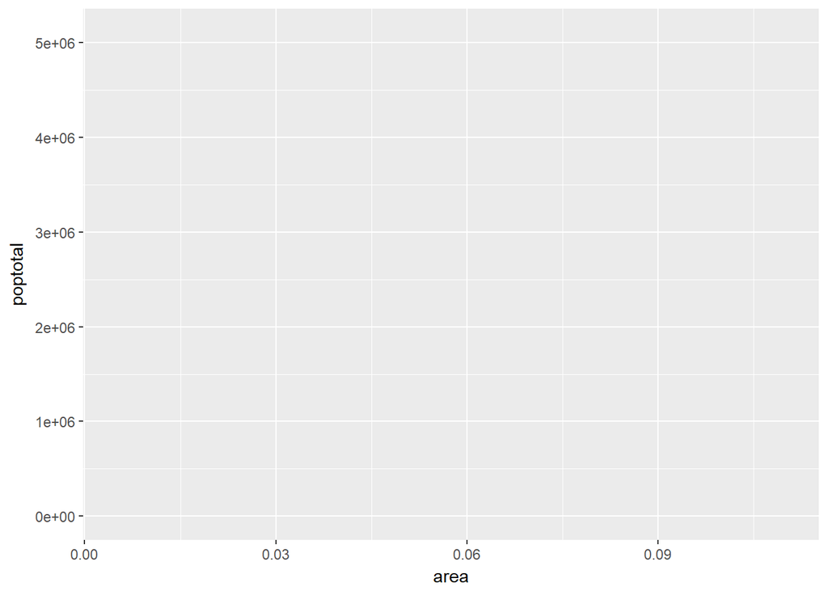

```r
ggplot(midwest, aes(x = area, y = poptotal))
```

### Philosophical Discussion

No, not Plato. So why didn’t that plot work? It’s becuase of the design philosophy behind ggplot2. Markers in ggplot2, called ‘geoms’ are added in layers. What that statement essentially did was create a plot in ggplot2 with the correct axes, and data, and scale. The thing is we didn’t tell it how to show the data. So let’s do that.

Also, while we are at it, let’s get rid of the scientific numbering.

```r
options(scipen = 999)
```

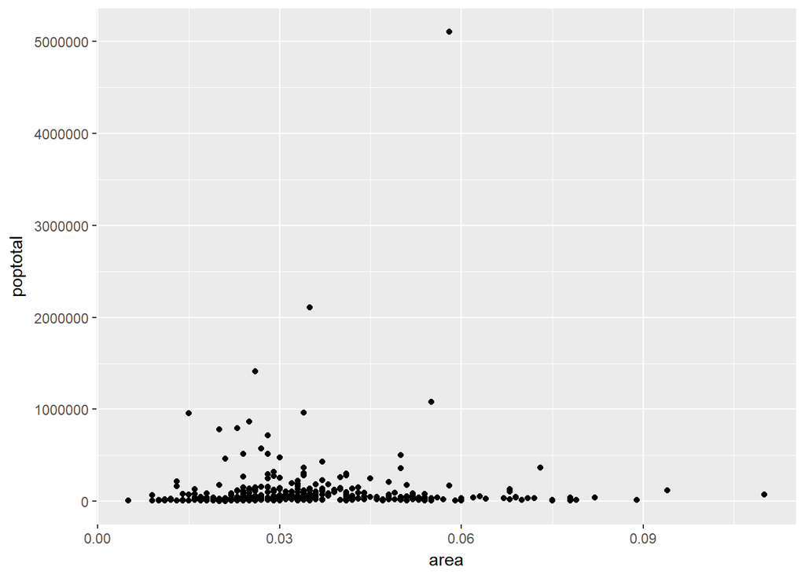

```r
ggplot(midwest, aes(x = area, y = poptotal)) +
  geom_point()
```

Another way to do this:

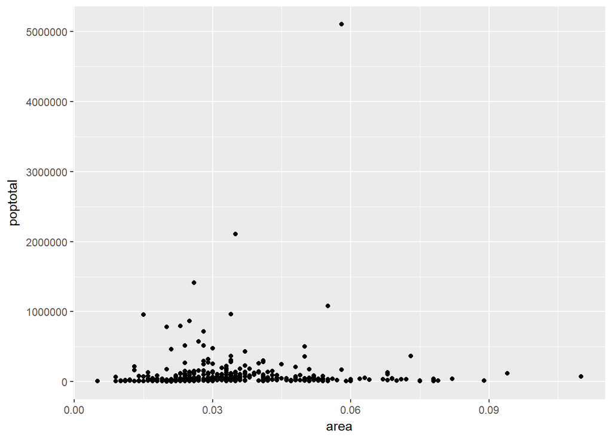

```r
ggplot(midwest) +
  geom_point(aes(x = area, y = poptotal))
```

### Layer upon Layer

Just to make the layered nature of ggplot2 plots more apparent, moving forward, we’re going to store the map in an object and add layers to it and plot it along the way.

```r
# This is the blank plot that we had at first, but instead of directly plotting it, we are storing it in an object
gg_scat <- ggplot(midwest, aes(x = area, y = poptotal))
```

But before we add the points…

### It’s not always black and white

Okay now that we know how to plot a graph, let’s add some color to it. So, I’ve been told that midwest US has a number of states, and that they are in fact different. So let’s go ahead and represent that. Also, we could probably use larger points.

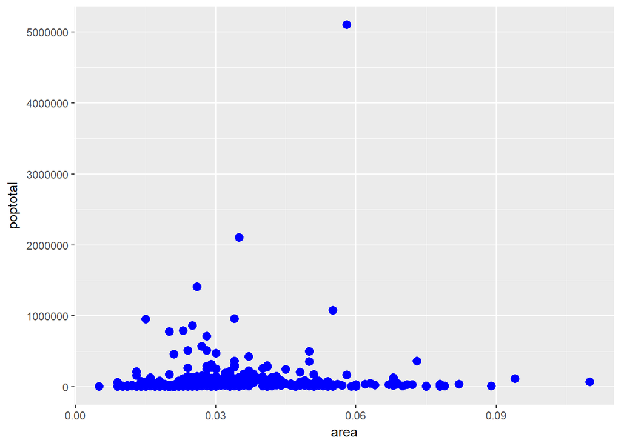

```r
gg_scat +
  geom_point(col='blue', size=3)
```

But that’s equally ugh-ly. So let’s color this by the State that the county belongs to instead.

First try:

```r
gg_scat +
  geom_point(col=state, size=3)
```

Why did that not work? The ‘col’ atrribute inside geom_point (or actually geom_anything) does not maintain the context of the data initiated originally withing the ggplot statement. So, let’s try explicitly mentioning that.

Second try:

```r
gg_scat +
  geom_point(col=midwest$state, size=3)
```

Why did that not work? The ‘col’ attribute is meant for accepting colors as an input, and not a set of categorical variables. For that, we would need to pass it within an aesthetics function.

Third time’s the charm:

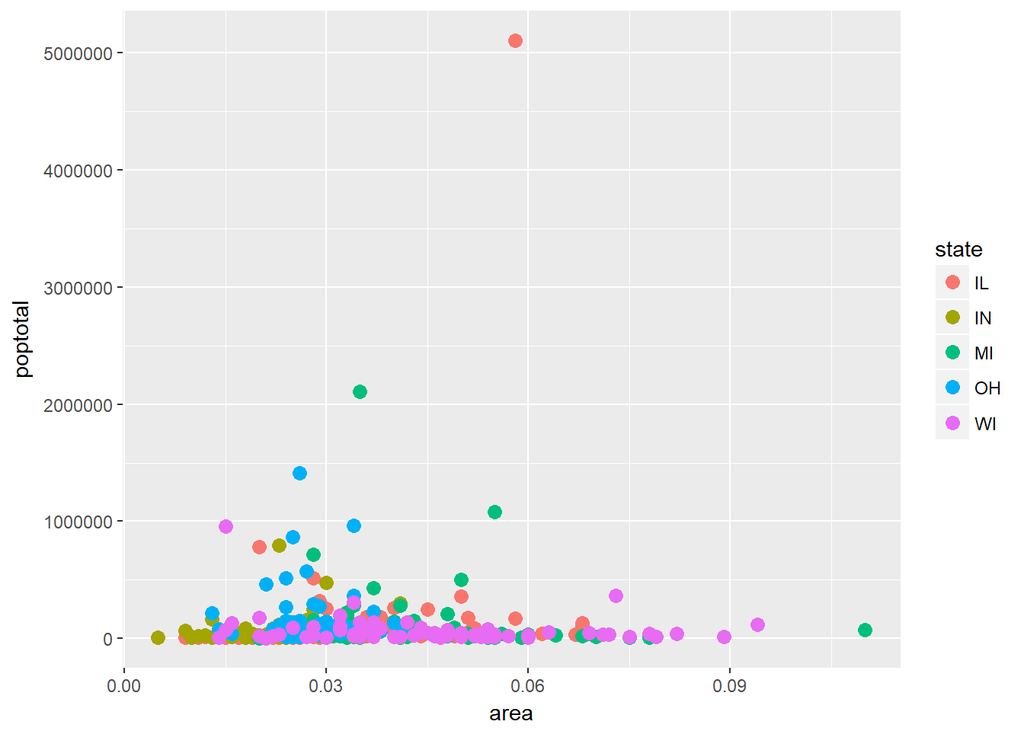

```r
gg_scat + geom_point(aes(col=state), size=3)
```

We can change the color palette too, to make it look more palette-able.

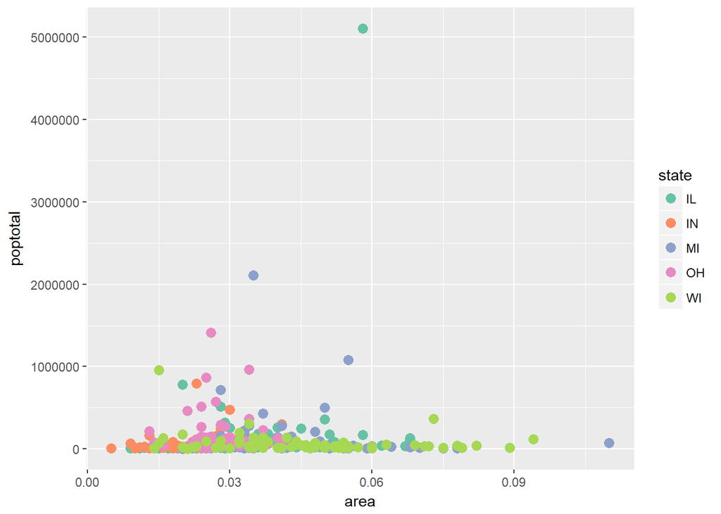

```r
gg_scat +
  geom_point(aes(col=state), size=3) +
  scale_color_brewer(palette = "Set2")
```

Now that we have assigned color to each state, let’s save that on to our ggplot object, and add titles to our graph.

```r
gg_scat <- gg_scat + geom_point(aes(col=state), size=3) + scale_color_brewer(palette = "Set2")
```

### Two ways to Title

While we’re sure there are more ways to put titles and axis labels on a graph in ggplot2, here are two common ones:

#### To lab or not to lab (Alternatively titled: P.S. I Lab You)

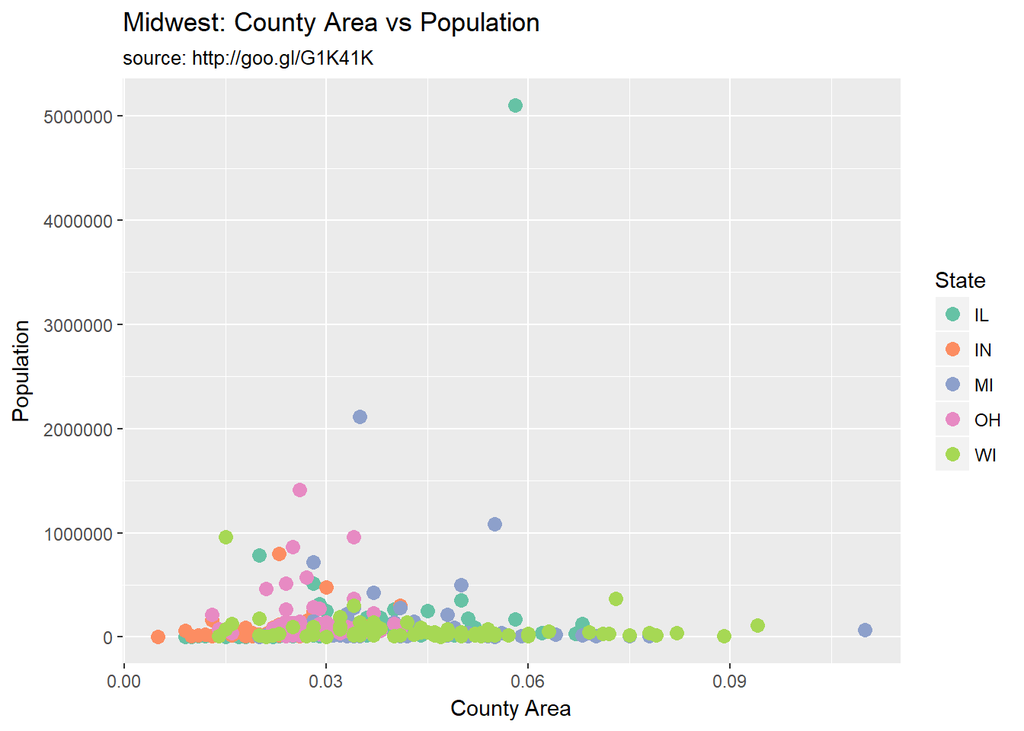

```r
gg_scat + labs(title="Midwest: County Area vs Population", subtitle="source: http://goo.gl/G1K41K", x = "County Area", y = "Population", color = "State")
```

#### GG, GG

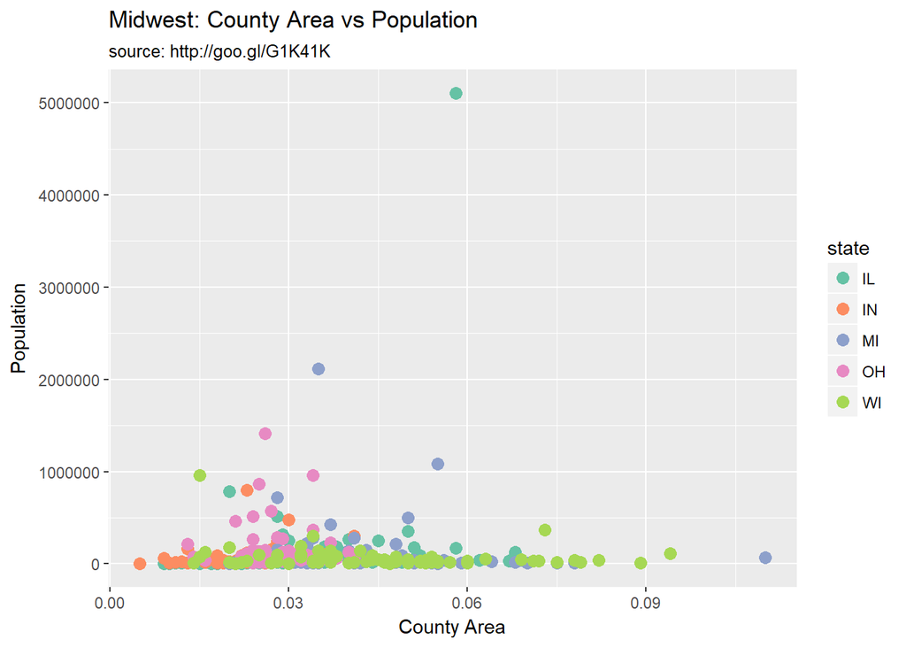

```r
gg_scat +
  ggtitle("Midwest: County Area vs Population", subtitle="source: http://goo.gl/G1K41K") +
  xlab("County Area") +
  ylab("Population")
```

#### So which one is the right one?

Well, it depends. Labs is the short hand method that gives us an easy way to add all of the labels and titles (even for the legends) in one go. Also, if you are planning to refine the graphs further in a tool like Adibe Illustrator, then this provides a quick way to just place the text. With ggtitle, xlab, and ylab we can attach ‘aes’ objects to the elements and really customize them at a granular level in ggplot iteslf. Although, one thing to note is that even using ‘labs’ one can customize granularly using ‘theme’, but fir this purpose, the ggtitle method is much more structured.

I’m just saving one of them to the plot.

```r
gg_scat <- gg_scat + labs(title="Midwest: County Area vs Population", subtitle="source: http://goo.gl/G1K41K", x = "County Area", y = "Population", color = "State")
```

## The closer you look…

Now that we have a plot that looks decent, let’s get down to the nitty-gritty of it. While there are many observations, the meat of the data lies in the bottom 1/5th of the graph. The rest can be treated as outliers. So let’s crop the graph.

So like everything in life, there are two ways to do this. To higlight the difference between the two, let’s add a smoothing line. This will become relevant shortly. Trust me.

#### So smooth

What this does is basically add a linear model (hence the ‘method = lm’) that tries to justify the spread in the data. Again, I’ll show in a bit why this becomes relevant to understand what’s happening.

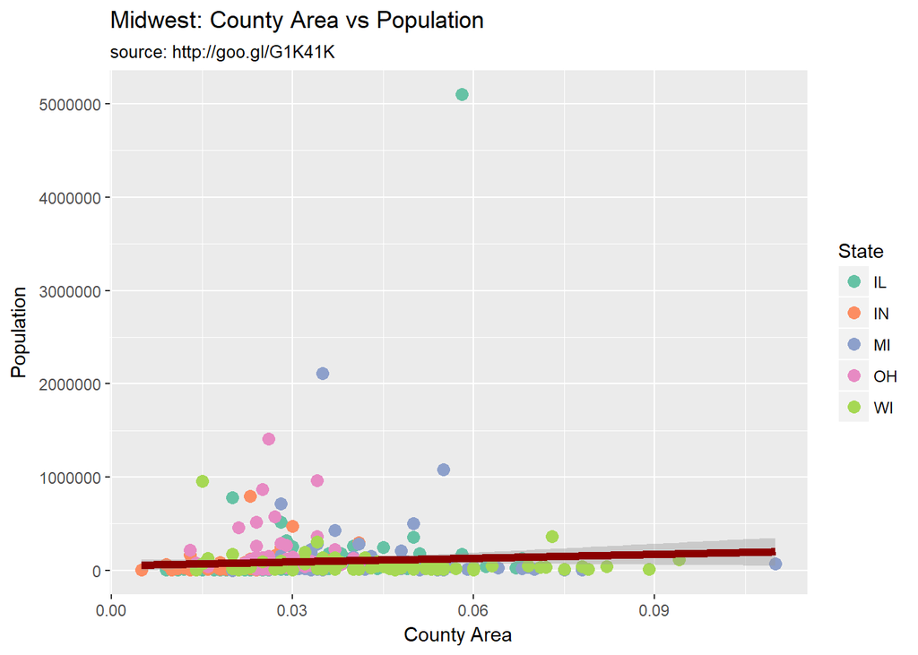

```r
gg_scat <- gg_scat + geom_smooth(method = "lm", col = 'darkred', size = 2)
gg_scat
```

Now, off with the excess.

### Method 1: Know your limits

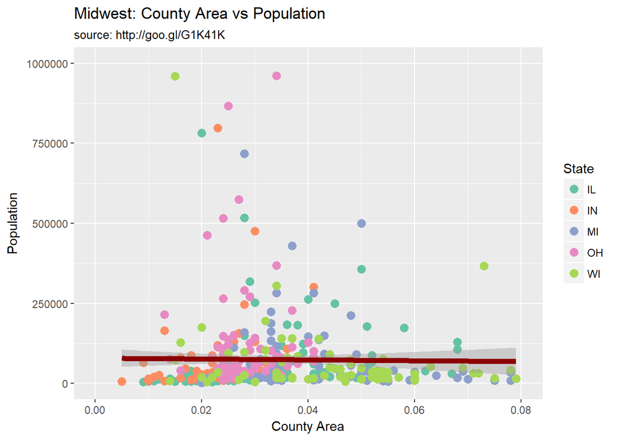

```r
gg_scat +
  xlim(c(0, 0.08)) +
  ylim(c(0, 1000000))
```

### Method 2: Zoomin

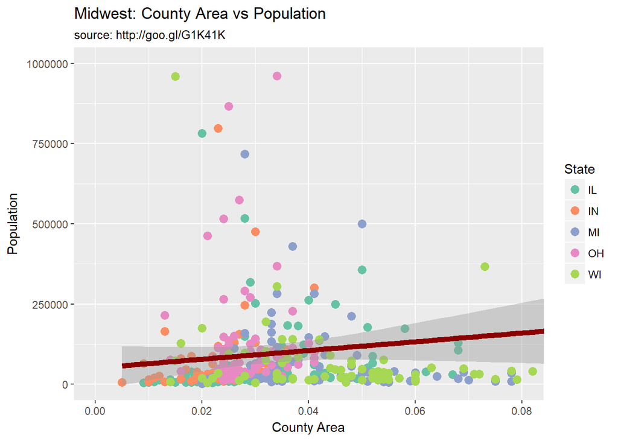

```r
gg_scat +
  coord_cartesian(xlim=c(0, 0.08), ylim = c(0, 1000000))
```

Do you see a difference between the two?

In the limiting approach (first graph), the line appears much more parallel to the x axis as compared to the zooming approach (second graph). This is because in the first approach, the smoothing line is calculated after the plot is made. It thus takes into account only the data that is present in the current plot, and does not try to run the linear model across the whole dataset. In the second approach, the whole plot is made, and then the area prescribed in the coordinate limits is ahown. So while the plot area shows only the selected section, the the smoothing line is for the entire dataset.

It’s not that one approach is wrong and the other is right. The limiting approach limits the data being considered for the plot, whereas the zooming approach focuses on a certain section of it. Both can be useful depending on the application.

Again I’m just saving one of them into our plot object.

```r
gg_scat <- gg_scat +
  xlim(c(0, 0.08)) +
  ylim(c(0, 1000000))
```

## Save our plots!

So now that we have a plot, let’s save it, and be done with it. You can also save it the old-fashioned way by hitting save from the plot window, but it deprives you of all the gggoodness. Enter ggsave.

```r
ggsave(filename = 'Midwest - County Area vs Population.pdf', plot = gg_scat, device = "pdf", width = 11, height = 8.5, units = "in")
```